# CMSC320_Final_Project

**Analysis of the Cost of Living Around the World**

Spring 2024 Data Science Project

Ryan Chng, Annika Wong

**Member Contribution:**

Ryan Chng: 100%

Annika Wong: 100%

"We, all team members, agree together that the above information is true, and we are confident about our contributions to this submitted project/final tutorial." Ryan Chng, Annika Wong - 5/7/2024

**Specifics:**

Ryan Chng: Worked together to develop ideas, curate and explore data, design and analyze ML algorithms, visualize and develop the overall conclusion. Focused moreso on data analysis.

Annika Wong: Worked together to develop ideas, curate and explore data, design and analyze ML algorithms, visualize and develop the overall conclusion. Focused moreso on data curation and development.

**1. Introduction**

As the years go by, the cost of living has only skyrocketed due to economic inflation. $30,000 was well enough to purchase a house and the many amenities tied to it in the past, but today it is barely enough to scrape by the annual cost of living in many parts of the world, much less the initial down payment for a property. More and more people around the world are struggling to make ends meet as the interest rates continue to rise to account for the inflation, leading to an alarming increase of unemployment rates as well. As college students, we are constantly concerned about the financial strain expenses such as tuition, housing, and dining contributes to the high cost of living. With the surge in lease prices for off-campus housing and grocery costs, we have become particularly aware of how the cost of living can contribute to economic stress in familial households. We aimed to determine the broader impact these fluctuations have throughout the US and globally.

Our datasets include a wide range of economic indicators, including unemployment rates, housing, food, and commodity prices, as well as data reflecting household expenses for varying family sizes. Since our dataset is organized into major cities and countries, we hope to analyze any correlations between geographical location, unemployment, and the overall cost of living, and how these current practices may not be practical or sustainable.

**2. Data Curation**

In order to start the data collection process, we needed a dataset to work with. All of our data was obtained through [Kaggle](https://https://www.kaggle.com/). Since we used Google Colab, we downloaded and uploaded the following datasets to our notebook in order to use them. Note that after reloading your notebook, you may have to reupload your datasets. For more information about google colab, please visit [Google Colab](https://colab.google/).

Cost of Living: https://www.kaggle.com/datasets/mvieira101/global-cost-of-living

Unemployment: https://www.kaggle.com/datasets/prasertk/inflation-interest-and-unemployment-rate

In this section, we will start by importing the necessary Python libraries that we will use throughout this tutorial.

```python
import pandas as pd
import scipy as sp
import numpy as np

# Data Visualization
import matplotlib.pyplot as plt

# ML
from sklearn.linear_model import LinearRegression
from sklearn.model_selection import train_test_split
from sklearn.metrics import mean_squared_error, r2_score
from sklearn.preprocessing import PolynomialFeatures
from sklearn.pipeline import make_pipeline
```

First, in order to understand our data, we used python's pandas library to work with the dataset. Using pandas, we read in our csv file and created a dataframe to allow for easy reading and querying.

> **Parsing our dataset**

> When looking at the brief overview for our dataset, we noticed that none of the column names were actually descriptive. Thus we created a dictionary mapping that would allow us to rename the columns from their previous names to a more descriptive and representative column name.

```python
cost_of_living_df = pd.read_csv('cost-of-living.csv')
cost_of_living_df.drop(columns = ["Unnamed: 0"], inplace = True)

# Rename Restaurant Cost Columns
cost_of_living_df.rename(columns = {
  "city" : "City",
  "country": "Country",
  "x1":	"Inexpensive Restaurant Meal",
  "x2":	"Mid-range Restaurant Meal",
  "x3":	"McDonalds McMeal",
  "x4":	"Domestic Beer in Restaurants",
  "x5":	"Imported Beer in Restaurants",
  "x6":	"Cappuccino in Restaurants",
  "x7":	"Coke/Pepsi in Restaurants",
  "x8":	"Water in Restaurants"
}, inplace = True)

# Renaming Food Cost Columns
cost_of_living_df.rename(columns = {
   "x9": "Milk",
  "x10":	"Loaf of White Bread",
  "x11":	"Rice",
  "x12": "Eggs",
  "x13":	"Cheese",
  "x14":	"Chicken Fillets",
  "x15":	"Beef",
  "x16":	"Apples",
  "x17":	"Banana",
  "x18":	"Oranges",
  "x19":	"Tomato",
  "x20":	"Potato",
  "x21":	"Onion",
  "x22":	"Lettuce",
  "x23":	"Water at the Market",
  "x24":	"Bottle of Wine at the Market",
  "x25":	"Domestic Beer at the Market",
  "x26":	"Imported Beer at the Market"
}, inplace = True)

# Replacing Other Necessities Cost Columns
cost_of_living_df.rename(columns = {
  "x27":	"Cigarettes 20 Pack",
  "x28":	"One-way Ticket (Local Transport)",
  "x29":	"Monthly Pass Tickets",
  "x30":	"Taxi Start (Normal Tariff)",
  "x31":	"Taxi 1km (Normal Tariff)",
  "x32":	"Taxi 1hour Waiting",
  "x33":	"Gasoline",
  "x34":	"Volkswagen Golf 1.4 90 KW Trendline",
  "x35":	"Toyota Corolla Sedan 1.6l 97kW Comfort",
  "x36":	"Basic Electricity, Heating, Cooling, Water, Garbage for 85m2 Apartment",
  "x37":	"1 min. of Prepaid Mobile Tariff Local (No Discounts or Plans)",
  "x38":	"Internet",
  "x39":	"Fitness Club Monthly Fee",
  "x40":	"Tennis Court Rent",
  "x41":	"Cinema 1 Seat Ticket",
  "x42":	"Preschool Private Monthly for 1 Child",
  "x43":	"International Primary School, Yearly for 1 Child",
  "x44":	"1 Pair of Jeans",
  "x45":	"1 Summer Dress in a Chain Store",
  "x46":	"1 Pair of Nike Running Shoes Mid-Range",
  "x47":	"1 Pair of Men Leather Business Shoes",
  "x48":	"Apartment 1 bedroom in City Centre",
  "x49":	"Apartment 1 bedroom Outside of Centre",
  "x50":	"Apartment 3 bedrooms in City Centre",
  "x51":	"Apartment 3 bedrooms Outside of Centre",
  "x52":	"Price per Square Meter to Buy Apartment in City Centre",
  "x53":	"Price per Square Meter to Buy Apartment Outside of Centre",
  "x54":	"Average Monthly Net Salary (After Tax)",
  "x55":	"Mortgage Interest Rate in Percentages (%), Yearly, for 20 Years Fixed-Rate"
}, inplace = True)

# The data given were floats/ints so we did not need to change them
# print(cost_of_living_df.dtypes)
```

Here we display an overview of our data, only including the rows in which our dataset classifies them with a data quality = 1 or rather that there is sufficient data in the row.

```python
# Cost of living data set based on only rows where the data_quality is given as 1
cost_of_living_df[cost_of_living_df['data_quality'] == 1]
```

|  | City | Country | Inexpensive Restaurant Meal | Mid-range Restaurant Meal | McDonalds McMeal | Domestic Beer in Restaurants | Imported Beer in Restaurants | Cappuccino in Restaurants | Coke/Pepsi in Restaurants | Water in Restaurants | ... | 1 Pair of Men Leather Business Shoes | Apartment 1 bedroom in City Centre | Apartment 1 bedroom Outside of Centre | Apartment 3 bedrooms in City Centre | Apartment 3 bedrooms Outside of Centre | Price per Square Meter to Buy Apartment in City Centre | Price per Square Meter to Buy Apartment Outside of Centre | Average Monthly Net Salary (After Tax) | Mortgage Interest Rate in Percentages (%), Yearly, for 20 Years Fixed-Rate | data_quality |
| --- | --- | --- | --- | --- | --- | --- | --- | --- | --- | --- | --- | --- | --- | --- | --- | --- | --- | --- | --- | --- | --- |
| 0 | Delhi | India | 4.90 | 22.04 | 4.28 | 1.84 | 3.67 | 1.78 | 0.48 | 0.19 | ... | 36.26 | 223.87 | 133.38 | 596.16 | 325.82 | 2,619.46 | 1,068.90 | 586.35 | 7.96 | 1 |
| 1 | Shanghai | China | 5.59 | 40.51 | 5.59 | 1.12 | 4.19 | 3.96 | 0.52 | 0.32 | ... | 121.19 | 1,080.07 | 564.30 | 2,972.57 | 1,532.23 | 17,333.09 | 9,174.88 | 1,382.83 | 5.01 | 1 |
| 2 | Jakarta | Indonesia | 2.54 | 22.25 | 3.50 | 2.02 | 3.18 | 2.19 | 0.59 | 0.27 | ... | 80.32 | 482.85 | 270.15 | 1,117.69 | 584.37 | 2,694.05 | 1,269.44 | 483.19 | 9.15 | 1 |
| 3 | Manila | Philippines | 3.54 | 27.40 | 3.54 | 1.24 | 1.90 | 2.91 | 0.93 | 0.51 | ... | 61.82 | 559.52 | 281.78 | 1,754.40 | 684.81 | 3,536.04 | 2,596.44 | 419.02 | 7.80 | 1 |
| 4 | Seoul | South Korea | 7.16 | 52.77 | 6.03 | 3.02 | 4.52 | 3.86 | 1.46 | 0.78 | ... | 108.30 | 809.83 | 583.60 | 2,621.05 | 1,683.74 | 21,847.94 | 10,832.90 | 2,672.23 | 3.47 | 1 |
| ... | ... | ... | ... | ... | ... | ... | ... | ... | ... | ... | ... | ... | ... | ... | ... | ... | ... | ... | ... | ... | ... |
| 4145 | Haugesund | Norway | 15.37 | 80.43 | 12.06 | 8.60 | 8.55 | 4.32 | 3.34 | 2.87 | ... | 120.62 | 703.75 | 552.95 | 1,306.93 | 1,080.73 | 2,473.18 | 2,243.39 | 3,310.20 | 2.57 | 1 |
| 4258 | Lagos | Portugal | 8.31 | 62.32 | 7.27 | 2.60 | 2.60 | 1.77 | 1.77 | 1.42 | ... | 60.24 | 869.91 | 706.31 | 1,627.29 | 1,201.74 | 3,467.10 | 3,401.40 | 910.11 | 3.33 | 1 |
| 4341 | Porto Calvo | Brazil | 4.66 | 25.16 | 5.59 | 1.86 | 2.24 | 1.69 | 1.03 | 0.69 | ... | 45.65 | 298.14 | 241.46 | 542.24 | 444.88 | 1,229.83 | 1,071.44 | 385.78 | 8.17 | 1 |
| 4426 | Fairfax | United States | 19.38 | 75.00 | 10.00 | 6.00 | 7.62 | 5.06 | 2.42 | 1.78 | ... | 129.00 | 2,200.00 | 1,733.33 | 3,560.00 | 2,825.00 | 6,754.35 | 2,891.90 | 6,117.78 | 4.90 | 1 |
| 4429 | Kalach-na-Donu | Russia | 8.52 | 49.13 | 6.14 | 1.31 | 2.29 | 2.50 | 1.01 | 0.51 | ... | 105.00 | 484.26 | 318.42 | 675.51 | 491.28 | 2,006.06 | 1,250.03 | 608.16 | 10.68 | 1 |

910 rows × 58 columns

> In our dataset, we noticed that there were various categories that the columns could be split into. As a result, we decided to separate the costs in our data table into multiple categories that we saw fit to analyze. We also chose to append the column containing the Average Monthly Net Salary to all of our dataframe categories to allow for easier comparison.
> - Food Costs (Restaurant Vs Market)
> - Transportation
> - Housing
> - Miscellaneous/Non-Necessary
> - Clothing
> - Schooling

```python
# Food Costs

# Restaurant Costs
restaurant_costs_df = pd.concat([cost_of_living_df.iloc[:, 0:10], cost_of_living_df.iloc[:, 55:56]], axis = 1)
restaurant_costs_df
```

|  | City | Country | Inexpensive Restaurant Meal | Mid-range Restaurant Meal | McDonalds McMeal | Domestic Beer in Restaurants | Imported Beer in Restaurants | Cappuccino in Restaurants | Coke/Pepsi in Restaurants | Water in Restaurants | Average Monthly Net Salary (After Tax) |
| --- | --- | --- | --- | --- | --- | --- | --- | --- | --- | --- | --- |
| 0 | Delhi | India | 4.90 | 22.04 | 4.28 | 1.84 | 3.67 | 1.78 | 0.48 | 0.19 | 586.35 |
| 1 | Shanghai | China | 5.59 | 40.51 | 5.59 | 1.12 | 4.19 | 3.96 | 0.52 | 0.32 | 1,382.83 |
| 2 | Jakarta | Indonesia | 2.54 | 22.25 | 3.50 | 2.02 | 3.18 | 2.19 | 0.59 | 0.27 | 483.19 |
| 3 | Manila | Philippines | 3.54 | 27.40 | 3.54 | 1.24 | 1.90 | 2.91 | 0.93 | 0.51 | 419.02 |
| 4 | Seoul | South Korea | 7.16 | 52.77 | 6.03 | 3.02 | 4.52 | 3.86 | 1.46 | 0.78 | 2,672.23 |
| ... | ... | ... | ... | ... | ... | ... | ... | ... | ... | ... | ... |
| 4869 | Peterborough | Australia | NaN | NaN | NaN | NaN | NaN | NaN | NaN | NaN | NaN |
| 4870 | Georgetown | Australia | NaN | NaN | NaN | NaN | NaN | NaN | NaN | NaN | NaN |
| 4871 | Ixtapa Zihuatanejo | Mexico | 5.19 | 31.13 | 12.97 | 0.99 | NaN | 1.82 | 0.62 | 0.42 | NaN |
| 4872 | Iqaluit | Canada | 29.78 | 74.61 | 13.77 | 6.70 | 8.93 | 3.72 | 3.54 | 4.10 | NaN |
| 4873 | Neiafu | Tonga | NaN | 29.53 | 10.55 | 10.55 | NaN | NaN | 2.11 | 2.11 | NaN |

4874 rows × 11 columns

```python
# Market Costs
market_costs_df = pd.concat([cost_of_living_df.iloc[:, 0:2], cost_of_living_df.iloc[:, 10:28], cost_of_living_df.iloc[:, 55:56]], axis = 1)
market_costs_df
```

|  | City | Country | Milk | Loaf of White Bread | Rice | Eggs | Cheese | Chicken Fillets | Beef | Apples | ... | Oranges | Tomato | Potato | Onion | Lettuce | Water at the Market | Bottle of Wine at the Market | Domestic Beer at the Market | Imported Beer at the Market | Average Monthly Net Salary (After Tax) |
| --- | --- | --- | --- | --- | --- | --- | --- | --- | --- | --- | --- | --- | --- | --- | --- | --- | --- | --- | --- | --- | --- |
| 0 | Delhi | India | 0.73 | 0.51 | 0.88 | 1.01 | 4.32 | 3.79 | 5.57 | 1.80 | ... | 1.01 | 0.60 | 0.36 | 0.41 | 0.70 | 0.36 | 9.79 | 1.53 | 2.51 | 586.35 |
| 1 | Shanghai | China | 2.68 | 2.57 | 1.18 | 2.17 | 18.01 | 4.67 | 12.79 | 2.22 | ... | 2.11 | 1.47 | 0.82 | 1.02 | 0.82 | 0.62 | 13.97 | 0.91 | 1.93 | 1,382.83 |
| 2 | Jakarta | Indonesia | 1.28 | 1.21 | 0.83 | 1.70 | 6.66 | 3.46 | 8.32 | 2.80 | ... | 2.08 | 1.24 | 1.35 | 2.10 | 1.13 | 0.42 | 20.66 | 2.06 | 3.18 | 483.19 |
| 3 | Manila | Philippines | 1.63 | 1.19 | 0.89 | 1.73 | 5.06 | 4.19 | 6.64 | 2.66 | ... | 2.95 | 1.42 | 1.76 | 1.75 | 1.36 | 0.65 | 8.84 | 1.15 | 1.55 | 419.02 |
| 4 | Seoul | South Korea | 2.13 | 2.78 | 3.66 | 4.02 | 11.13 | 10.62 | 40.41 | 6.79 | ... | 6.40 | 6.36 | 3.86 | 2.81 | 2.40 | 1.06 | 15.08 | 2.10 | 2.49 | 2,672.23 |
| ... | ... | ... | ... | ... | ... | ... | ... | ... | ... | ... | ... | ... | ... | ... | ... | ... | ... | ... | ... | ... | ... |
| 4869 | Peterborough | Australia | NaN | NaN | NaN | NaN | NaN | NaN | NaN | NaN | ... | NaN | NaN | NaN | NaN | NaN | NaN | NaN | NaN | NaN | NaN |
| 4870 | Georgetown | Australia | NaN | NaN | NaN | NaN | NaN | NaN | NaN | NaN | ... | NaN | NaN | NaN | NaN | NaN | NaN | NaN | NaN | NaN | NaN |
| 4871 | Ixtapa Zihuatanejo | Mexico | 1.82 | 0.78 | NaN | 1.25 | NaN | NaN | NaN | NaN | ... | NaN | NaN | NaN | NaN | NaN | 0.78 | NaN | NaN | NaN | NaN |
| 4872 | Iqaluit | Canada | 2.54 | 2.97 | 6.89 | 3.72 | 8.84 | 11.94 | 11.49 | 5.96 | ... | 6.45 | 3.86 | 3.61 | 3.86 | 3.36 | 4.03 | 14.89 | NaN | NaN | NaN |
| 4873 | Neiafu | Tonga | 1.56 | 0.84 | NaN | 3.04 | NaN | 2.53 | 5.06 | 2.53 | ... | 2.53 | 2.53 | 2.11 | NaN | NaN | NaN | 12.66 | NaN | NaN | NaN |

4874 rows × 21 columns

```python
# Transportation Costs
transportation_costs_df = pd.concat([cost_of_living_df.iloc[:, 0:2], cost_of_living_df.iloc[:, 29:37], cost_of_living_df.iloc[:, 55:56]], axis = 1)
transportation_costs_df
```

|  | City | Country | One-way Ticket (Local Transport) | Monthly Pass Tickets | Taxi Start (Normal Tariff) | Taxi 1km (Normal Tariff) | Taxi 1hour Waiting | Gasoline | Volkswagen Golf 1.4 90 KW Trendline | Toyota Corolla Sedan 1.6l 97kW Comfort | Average Monthly Net Salary (After Tax) |
| --- | --- | --- | --- | --- | --- | --- | --- | --- | --- | --- | --- |
| 0 | Delhi | India | 0.49 | 11.63 | 0.61 | 0.22 | 1.22 | 1.25 | 12,242.64 | 22,972.31 | 586.35 |
| 1 | Shanghai | China | 0.56 | 27.94 | 2.10 | 0.42 | 8.38 | 1.17 | 19,554.98 | 20,360.82 | 1,382.83 |
| 2 | Jakarta | Indonesia | 0.22 | 9.53 | 0.41 | 0.29 | 2.86 | 0.79 | 25,489.74 | 27,978.73 | 483.19 |
| 3 | Manila | Philippines | 0.53 | 11.86 | 0.71 | 0.24 | 2.12 | 1.38 | 22,984.03 | 18,200.60 | 419.02 |
| 4 | Seoul | South Korea | 0.98 | 41.47 | 2.86 | 0.90 | 9.05 | 1.41 | 28,648.67 | 26,851.06 | 2,672.23 |
| ... | ... | ... | ... | ... | ... | ... | ... | ... | ... | ... | ... |
| 4869 | Peterborough | Australia | NaN | NaN | NaN | NaN | NaN | NaN | NaN | NaN | NaN |
| 4870 | Georgetown | Australia | NaN | NaN | NaN | NaN | NaN | NaN | NaN | NaN | NaN |
| 4871 | Ixtapa Zihuatanejo | Mexico | NaN | NaN | 4.15 | 1.04 | 5.19 | 1.01 | NaN | NaN | NaN |
| 4872 | Iqaluit | Canada | 6.33 | NaN | 5.96 | NaN | NaN | NaN | NaN | NaN | NaN |
| 4873 | Neiafu | Tonga | NaN | NaN | NaN | NaN | NaN | NaN | NaN | NaN | NaN |

4874 rows × 11 columns

```python
# Miscellaneous/Non-Necessary Costs
misc_costs_df = pd.concat([cost_of_living_df.iloc[:, 0:2], cost_of_living_df.iloc[:, 41:43], cost_of_living_df.iloc[:, 55:56]], axis = 1)
misc_costs_df
```

|  | City | Country | Tennis Court Rent | Cinema 1 Seat Ticket | Average Monthly Net Salary (After Tax) |
| --- | --- | --- | --- | --- | --- |
| 0 | Delhi | India | 8.47 | 4.90 | 586.35 |
| 1 | Shanghai | China | 14.67 | 8.38 | 1,382.83 |
| 2 | Jakarta | Indonesia | 11.71 | 3.18 | 483.19 |
| 3 | Manila | Philippines | 5.85 | 5.48 | 419.02 |
| 4 | Seoul | South Korea | 17.99 | 9.42 | 2,672.23 |
| ... | ... | ... | ... | ... | ... |
| 4869 | Peterborough | Australia | NaN | NaN | NaN |
| 4870 | Georgetown | Australia | NaN | NaN | NaN |
| 4871 | Ixtapa Zihuatanejo | Mexico | 25.94 | 7.78 | NaN |
| 4872 | Iqaluit | Canada | NaN | 10.05 | NaN |
| 4873 | Neiafu | Tonga | NaN | NaN | NaN |

4874 rows × 5 columns

```python
# Clothing Costs
clothing_costs_df = pd.concat([cost_of_living_df.iloc[:, 0:2], cost_of_living_df.iloc[:, 45:49], cost_of_living_df.iloc[:, 55:56]], axis = 1)
clothing_costs_df
```

|  | City | Country | 1 Pair of Jeans | 1 Summer Dress in a Chain Store | 1 Pair of Nike Running Shoes Mid-Range | 1 Pair of Men Leather Business Shoes | Average Monthly Net Salary (After Tax) |
| --- | --- | --- | --- | --- | --- | --- | --- |
| 0 | Delhi | India | 32.05 | 33.34 | 49.35 | 36.26 | 586.35 |
| 1 | Shanghai | China | 69.17 | 34.26 | 86.55 | 121.19 | 1,382.83 |
| 2 | Jakarta | Indonesia | 38.87 | 25.95 | 72.89 | 80.32 | 483.19 |
| 3 | Manila | Philippines | 38.45 | 26.96 | 69.47 | 61.82 | 419.02 |
| 4 | Seoul | South Korea | 56.99 | 45.49 | 70.21 | 108.30 | 2,672.23 |
| ... | ... | ... | ... | ... | ... | ... | ... |
| 4869 | Peterborough | Australia | NaN | NaN | NaN | NaN | NaN |
| 4870 | Georgetown | Australia | NaN | NaN | NaN | NaN | NaN |
| 4871 | Ixtapa Zihuatanejo | Mexico | 31.13 | 36.32 | 77.83 | 103.78 | NaN |
| 4872 | Iqaluit | Canada | NaN | NaN | NaN | NaN | NaN |
| 4873 | Neiafu | Tonga | NaN | NaN | NaN | NaN | NaN |

4874 rows × 7 columns

```python
# Housing Costs
housing_costs_df = pd.concat([cost_of_living_df.iloc[:, 0:2], cost_of_living_df.iloc[:, 37:40], cost_of_living_df.iloc[:, 49:55], cost_of_living_df.iloc[:, 55:56]], axis = 1)
housing_costs_df
```

|  | City | Country | Basic Electricity, Heating, Cooling, Water, Garbage for 85m2 Apartment | 1 min. of Prepaid Mobile Tariff Local (No Discounts or Plans) | Internet | Apartment 1 bedroom in City Centre | Apartment 1 bedroom Outside of Centre | Apartment 3 bedrooms in City Centre | Apartment 3 bedrooms Outside of Centre | Price per Square Meter to Buy Apartment in City Centre | Price per Square Meter to Buy Apartment Outside of Centre | Average Monthly Net Salary (After Tax) |
| --- | --- | --- | --- | --- | --- | --- | --- | --- | --- | --- | --- | --- |
| 0 | Delhi | India | 57.37 | 0.01 | 7.96 | 223.87 | 133.38 | 596.16 | 325.82 | 2,619.46 | 1,068.90 | 586.35 |
| 1 | Shanghai | China | 64.76 | 0.03 | 16.74 | 1,080.07 | 564.30 | 2,972.57 | 1,532.23 | 17,333.09 | 9,174.88 | 1,382.83 |
| 2 | Jakarta | Indonesia | 80.12 | 0.11 | 30.45 | 482.85 | 270.15 | 1,117.69 | 584.37 | 2,694.05 | 1,269.44 | 483.19 |
| 3 | Manila | Philippines | 97.45 | 0.15 | 38.02 | 559.52 | 281.78 | 1,754.40 | 684.81 | 3,536.04 | 2,596.44 | 419.02 |
| 4 | Seoul | South Korea | 176.24 | 0.16 | 22.06 | 809.83 | 583.60 | 2,621.05 | 1,683.74 | 21,847.94 | 10,832.90 | 2,672.23 |
| ... | ... | ... | ... | ... | ... | ... | ... | ... | ... | ... | ... | ... |
| 4869 | Peterborough | Australia | NaN | NaN | NaN | NaN | NaN | NaN | NaN | NaN | NaN | NaN |
| 4870 | Georgetown | Australia | NaN | NaN | NaN | NaN | NaN | NaN | NaN | NaN | NaN | NaN |
| 4871 | Ixtapa Zihuatanejo | Mexico | 77.83 | NaN | 27.63 | 415.11 | 259.44 | 518.89 | 415.11 | NaN | NaN | NaN |
| 4872 | Iqaluit | Canada | 260.58 | 0.07 | 84.38 | NaN | NaN | 2,978.11 | 2,978.11 | NaN | NaN | NaN |
| 4873 | Neiafu | Tonga | NaN | NaN | NaN | NaN | NaN | NaN | NaN | NaN | NaN | NaN |

4874 rows × 12 columns

```python
# School Costs
school_costs_df = pd.concat([cost_of_living_df.iloc[:, 0:2], cost_of_living_df.iloc[:, 43:45], cost_of_living_df.iloc[:, 55:56]], axis = 1)
school_costs_df
```

|  | City | Country | Preschool Private Monthly for 1 Child | International Primary School, Yearly for 1 Child | Average Monthly Net Salary (After Tax) |
| --- | --- | --- | --- | --- | --- |
| 0 | Delhi | India | 73.76 | 1,985.70 | 586.35 |
| 1 | Shanghai | China | 1,356.63 | 25,883.49 | 1,382.83 |
| 2 | Jakarta | Indonesia | 132.74 | 9,934.37 | 483.19 |
| 3 | Manila | Philippines | 254.89 | 10,860.59 | 419.02 |
| 4 | Seoul | South Korea | 384.01 | 18,283.99 | 2,672.23 |
| ... | ... | ... | ... | ... | ... |
| 4869 | Peterborough | Australia | NaN | NaN | NaN |
| 4870 | Georgetown | Australia | NaN | NaN | NaN |
| 4871 | Ixtapa Zihuatanejo | Mexico | NaN | NaN | NaN |
| 4872 | Iqaluit | Canada | NaN | NaN | NaN |
| 4873 | Neiafu | Tonga | NaN | NaN | NaN |

4874 rows × 5 columns

**3. Data Exploration/Summary Statistics**

Additionally, we noticed that there were a lot of missing values, for rows/cities with missing data, it was typically the whole row. We believe that these cities did not have data as they could be lower income or smaller cities which do not record such data. This data would be categorized as Data Missing Not at Random (NMAR). However, in the context of the dataset, we determined that since this data set seems to include all the cities known in the world, there may be some cities that could not have data collected. Therefore, we realized that it would be impossible to determine these missing values just through the analysis of other cities in the same country due to the variablilty of quality of life and conditions. Thus, as one of our data cleaning steps, we decided to drop rows where no data was collected and only contained NaN values.

However, there were also some countries that were missing only some values, thus for these rows, we decided to utilize the "data quality" column provided in our dataset along to better understand whether or not there was sufficient enough data to keep the row for analysis. Before dropping these values, we also decided to utilize our spliting of data frames into categories to minimize the amount of data loss due to dropping our NaN values.

> **Analysis of Outliers "Total Cost" of living**

> To simplify, we wanted to get an overview of our data and see which cities/countries had higher costs of living compared others We decided to drop rows with any NaN values for this section because we were analyzing the "Total Cost" by summing each column (having a NaN would mess with the overall Total Cost). Additionally, since a lot of these rows that contain NaN often have a large quantity of data missing for their columns, we noted that this meant that there was not sufficient data to analyze the city in the first place.

In this code snippet, we decided to create a new feature called Total Costs which would allow us to analyze the overall cost of living for each city. We did this by summing all the values across each city row and thus for purposes of total costs we ended up dropping rows with insufficient data/ NaN values which would interfere with the calculation of Total Cost.

```
count     1,264.00
mean     68,761.08
std      25,616.80
min      22,070.95
25%      51,561.42
50%      66,439.84
75%      81,360.65
max     348,248.40
Name: Total Costs, dtype: float64
```

|  | City | Country | Total Costs | Inexpensive Restaurant Meal | Mid-range Restaurant Meal | McDonalds McMeal | Domestic Beer in Restaurants | Imported Beer in Restaurants | Cappuccino in Restaurants | Coke/Pepsi in Restaurants | ... | 1 Pair of Men Leather Business Shoes | Apartment 1 bedroom in City Centre | Apartment 1 bedroom Outside of Centre | Apartment 3 bedrooms in City Centre | Apartment 3 bedrooms Outside of Centre | Price per Square Meter to Buy Apartment in City Centre | Price per Square Meter to Buy Apartment Outside of Centre | Average Monthly Net Salary (After Tax) | Mortgage Interest Rate in Percentages (%), Yearly, for 20 Years Fixed-Rate | data_quality |
| --- | --- | --- | --- | --- | --- | --- | --- | --- | --- | --- | --- | --- | --- | --- | --- | --- | --- | --- | --- | --- | --- |
| 0 | Delhi | India | 43,183.60 | 4.90 | 22.04 | 4.28 | 1.84 | 3.67 | 1.78 | 0.48 | ... | 36.26 | 223.87 | 133.38 | 596.16 | 325.82 | 2,619.46 | 1,068.90 | 586.35 | 7.96 | 1 |
| 1 | Shanghai | China | 101,858.25 | 5.59 | 40.51 | 5.59 | 1.12 | 4.19 | 3.96 | 0.52 | ... | 121.19 | 1,080.07 | 564.30 | 2,972.57 | 1,532.23 | 17,333.09 | 9,174.88 | 1,382.83 | 5.01 | 1 |
| 2 | Jakarta | Indonesia | 70,936.79 | 2.54 | 22.25 | 3.50 | 2.02 | 3.18 | 2.19 | 0.59 | ... | 80.32 | 482.85 | 270.15 | 1,117.69 | 584.37 | 2,694.05 | 1,269.44 | 483.19 | 9.15 | 1 |
| 3 | Manila | Philippines | 62,640.96 | 3.54 | 27.40 | 3.54 | 1.24 | 1.90 | 2.91 | 0.93 | ... | 61.82 | 559.52 | 281.78 | 1,754.40 | 684.81 | 3,536.04 | 2,596.44 | 419.02 | 7.80 | 1 |
| 4 | Seoul | South Korea | 116,052.65 | 7.16 | 52.77 | 6.03 | 3.02 | 4.52 | 3.86 | 1.46 | ... | 108.30 | 809.83 | 583.60 | 2,621.05 | 1,683.74 | 21,847.94 | 10,832.90 | 2,672.23 | 3.47 | 1 |
| ... | ... | ... | ... | ... | ... | ... | ... | ... | ... | ... | ... | ... | ... | ... | ... | ... | ... | ... | ... | ... | ... |
| 4727 | Erlenbach am Main | Germany | 82,882.16 | 15.58 | 51.93 | 8.31 | 4.15 | 4.15 | 3.40 | 2.54 | ... | 119.45 | 804.99 | 640.53 | 2,129.33 | 1,256.82 | 7,042.36 | 4,050.92 | 2,445.27 | 2.35 | 0 |
| 4732 | Gig Harbor | United States | 91,048.38 | 12.00 | 40.00 | 10.50 | 7.00 | 6.00 | 5.15 | 2.48 | ... | 101.67 | 1,800.00 | 2,000.00 | 3,000.00 | 2,400.00 | 3,821.19 | 2,852.44 | 4,500.00 | 5.22 | 0 |
| 4846 | Murovani Kurylivtsi | Ukraine | 35,263.13 | 2.71 | 12.17 | 2.68 | 0.67 | 1.08 | 0.68 | 0.24 | ... | 60.87 | 108.21 | 94.68 | 162.31 | 121.74 | 236.71 | 229.94 | 363.85 | 13.05 | 0 |
| 4863 | Tirupati | India | 30,597.51 | 2.45 | 9.18 | 4.28 | 2.11 | 3.06 | 2.01 | 0.46 | ... | 37.13 | 82.64 | 61.21 | 183.64 | 128.55 | 658.89 | 395.34 | 612.13 | 7.97 | 0 |
| 4867 | Egilsstadhir | Iceland | 63,318.75 | 17.30 | 70.61 | 8.47 | 4.24 | 3.53 | 3.95 | 1.77 | ... | 145.46 | 635.50 | 529.59 | 1,694.68 | 1,412.23 | 2,012.43 | 1,765.29 | 2,471.40 | 5.00 | 0 |

1264 rows × 59 columns

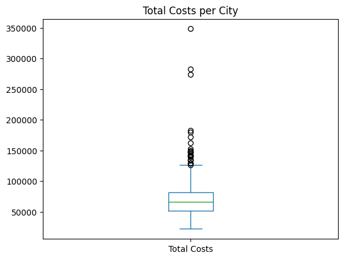

```python
# Finding Outliers focusing on Total Cost
pd.options.display.float_format = '{:,.2f}'.format

outliers_df = cost_of_living_df.copy()
outliers_df.dropna(axis = 0, inplace = True)
outliers_df.insert(2, "Total Costs", outliers_df.sum(axis = 1, numeric_only=True))

print(outliers_df['Total Costs'].describe())
outliers_df['Total Costs'].plot(kind='box', title='Total Costs per City')
outliers_df
```

> Analyzing Z-Scores

> To determine which cities had abnormally high costs of living we decided to use the z-scores and categorize cities into outlier cities (very high costs of living) and non-outlier cities (lower/average costs of living). To do so, we used querying techniques for dataframes to pick out the city names of scores over 2 and under -2 for outliers and between -2 and 2 for regular cities.

```python
z_score = sp.stats.zscore(outliers_df['Total Costs'], axis = 0)
outliers_df.insert(2, "z-score", z_score)
non_outliers_cities = outliers_df[(outliers_df['z-score'] > (-2)) & (outliers_df['z-score'] < 2)]['City']
outlier_cities = outliers_df[(outliers_df['z-score'] < (-2)) | (outliers_df['z-score'] > 2)]['City']

z_score_df = pd.concat([outliers_df['City'], outliers_df['Total Costs'], outliers_df['z-score']], axis = 1)
z_score_df_outliers = z_score_df[z_score_df['City'].isin(outlier_cities)]
z_score_df_non_outliers = z_score_df[z_score_df['City'].isin(non_outliers_cities)]
print("Outliers: ")
print(z_score_df_outliers)
print("Non-Outliers:")
print(z_score_df_non_outliers)
```

```
Outliers:
               City  Total Costs  z-score
20         New York   141,986.54     2.86
24           Tehran   129,241.63     2.36
64        Hong Kong   152,570.44     3.27
103       Singapore   282,416.62     8.34
115          Boston   121,391.21     2.06
215          Havana   172,115.37     4.04
241         Esfahan   180,153.49     4.35
296          Tabriz   273,700.86     8.00
429          Niamey   348,248.40    10.91
507            Bern   147,433.81     3.07
529        Hamilton   140,842.60     2.81
578      Kermanshah   182,687.77     4.45
653          Tyumen   121,116.63     2.04
```

[output cut: 32 more lines]

> As we can see, by analyzing the z-scores, we have a couple of cities that can be considered outliers when considering the "total cost" of living. Especially when looking at the names of the cities, we can recognize most as major cities with large populations as well as abnormally high living costs. When considering outliers, it makes a lot of sense that these cities have "Total Costs" that are outliers.

> **2) Analysis of Cost of Housing VS Average Net Salary**

> For this section, we wanted to analyze the cost of housing (especially since housing for college students is extremely expensive) in various cities across the world to see if there was any correlation with the average monthly Net Salary. We chose the one bedroom within/outside of city centre as a baseline for the cost of housing for one person.

> H0: Average Monthly Net Salary has no effect on the cost of a 1 bedroom apartment cost in the city centre

> HA: Average Monthly Net Salary has an effect on the cost of a 1 bedroom apartment cost in the city centre

```python
hypothesis_test_housing = pd.concat([cost_of_living_df.iloc[:, 0:2], cost_of_living_df['Apartment 1 bedroom in City Centre'], cost_of_living_df['Apartment 1 bedroom Outside of Centre'], cost_of_living_df['Average Monthly Net Salary (After Tax)']], axis = 1)
hypothesis_test_housing = hypothesis_test_housing.dropna()
hypothesis_test_housing
```

|  | City | Country | Apartment 1 bedroom in City Centre | Apartment 1 bedroom Outside of Centre | Average Monthly Net Salary (After Tax) |
| --- | --- | --- | --- | --- | --- |
| 0 | Delhi | India | 223.87 | 133.38 | 586.35 |
| 1 | Shanghai | China | 1,080.07 | 564.30 | 1,382.83 |
| 2 | Jakarta | Indonesia | 482.85 | 270.15 | 483.19 |
| 3 | Manila | Philippines | 559.52 | 281.78 | 419.02 |
| 4 | Seoul | South Korea | 809.83 | 583.60 | 2,672.23 |
| ... | ... | ... | ... | ... | ... |
| 4858 | Iola | United States | 600.00 | 450.00 | 3,333.33 |
| 4859 | Mackay | Australia | 726.51 | 670.62 | 3,688.43 |
| 4863 | Tirupati | India | 82.64 | 61.21 | 612.13 |
| 4865 | Rockhampton | Australia | 771.28 | 586.80 | 3,435.18 |
| 4867 | Egilsstadhir | Iceland | 635.50 | 529.59 | 2,471.40 |

2949 rows × 5 columns

> We decided to apply the Man-Whitney U-Test to compare if these two columns were from the same distribution since we were unsure if our data was normally distributed.

```python
statistic, p_value = sp.stats.mannwhitneyu(hypothesis_test_housing['Average Monthly Net Salary (After Tax)'], hypothesis_test_housing['Apartment 1 bedroom in City Centre'])


print("P-value:", p_value)
```

```
P-value: 1.9172555151133802e-192
```

> By using the Man-Whitney U-Test, we found that the p-value was significantly less than the standard alpha value 0.05, thereby disproving the null hypothesis and accept our alternative hypothesis that Average Monthly Net Salary has an effect on the cost of a 1 bedroom apartment cost in the city centre.

> As seen in our scatter plot, there seems to be a relatively strong relationship between Net Salary and Housing Costs. We see that relatively, as the amount paid for housing increases, so does the average net salary.

> Despite this, we also noted that the proportion at which the housing costs increase is much more drastic compared to the corresponding net salary. This would be something we would want to analyze especially since it tends to be that in some areas where housing costs are high, the net salary is low compared to other areas with cheaper housing costs.

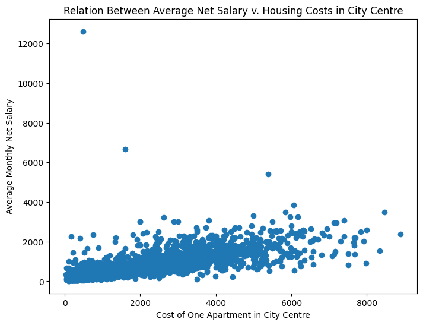

```python
plt.figure(figsize=(8, 6))
plt.scatter(hypothesis_test_housing['Average Monthly Net Salary (After Tax)'], hypothesis_test_housing['Apartment 1 bedroom in City Centre'])
plt.title('Relation Between Average Net Salary v. Housing Costs in City Centre')
plt.ylabel('Average Monthly Net Salary')
plt.xlabel('Cost of One Apartment in City Centre')
plt.show()
```

> According to our p-value, we should reject our Null Hypothesis since it is less than our alpha value 0.05 and accept our alternative hypothesis that Average Monthly Net Salary has an effect on the cost of a 1 bedroom apartment cost in the city centre.

> As seen in our scatter plot, there seems to be a relatively strong relationship between Net Salary and Housing Costs. We see that relatively, as the amount paid for housing increases, so does the average net salary.

> Despite this, we also noted that the proportion at which the housing costs increase is much more drastic compared to the corresponding net salary. This would be something we would want to analyze especially since it tends to be that in some areas where housing costs are high, the net salary is low compared to other areas with cheaper housing costs.

> **3) Analyzing if the average costs of each category is from the same distribution**

> In this section, we wanted to test if the costs of each category was proportional or if there were certain categories that were significantly different in cost than others.

> H0: There is no significant difference between the means of the categories of cost of living.

> HA: There is at least one category that has a mean that is significantly different from the others.

```python
# Finding the average costs of each category
restaurant_costs_df = restaurant_costs_df.dropna()
restaurant_costs_df.insert(2, "Average Cost", restaurant_costs_df.iloc[:,3:10].mean(axis = 1, numeric_only=True))

market_costs_df = market_costs_df.dropna()
market_costs_df.insert(2, "Average Cost", market_costs_df.iloc[:,3:20].mean(axis = 1, numeric_only=True))

transportation_costs_df = transportation_costs_df.dropna()
transportation_costs_df.insert(2, "Average Cost", transportation_costs_df.iloc[:,3:10].mean(axis = 1, numeric_only=True))

housing_costs_df = housing_costs_df.dropna()
housing_costs_df.insert(2, "Average Cost", housing_costs_df.iloc[:,3:9].mean(axis = 1, numeric_only=True))

misc_costs_df = misc_costs_df.dropna()
misc_costs_df.insert(2, "Average Cost", misc_costs_df.iloc[:,3:4].mean(axis = 1, numeric_only=True))

clothing_costs_df = clothing_costs_df.dropna()
clothing_costs_df.insert(2, "Average Cost", clothing_costs_df.iloc[:,3:6].mean(axis = 1, numeric_only=True))

school_costs_df = school_costs_df.dropna()
school_costs_df.insert(2, "Average Cost", school_costs_df.iloc[:,3:4].mean(axis = 1, numeric_only=True))
```

```python
sp.stats.f_oneway(restaurant_costs_df['Average Cost'], market_costs_df['Average Cost'], transportation_costs_df['Average Cost'], housing_costs_df['Average Cost'], misc_costs_df['Average Cost'], clothing_costs_df['Average Cost'], school_costs_df['Average Cost'], axis = 0)
```

```
F_onewayResult(statistic=3685.0209471880444, pvalue=0.0)
```

> Since we got a p value of 0, we decided to conduct a post hoc test. According to the ANOVA test, our p value is less than 0.05 thus we determine that there is at least one category that is significantly different from the others.

```python
print(sp.stats.tukey_hsd(restaurant_costs_df['Average Cost'], market_costs_df['Average Cost'], transportation_costs_df['Average Cost'], housing_costs_df['Average Cost'], misc_costs_df['Average Cost'], clothing_costs_df['Average Cost'], school_costs_df['Average Cost']))
```

```
Tukey's HSD Pairwise Group Comparisons (95.0% Confidence Interval)
Comparison  Statistic  p-value  Lower CI  Upper CI
 (0 - 1)      5.522     1.000  -222.404   233.447
 (0 - 2)  -6750.990     0.000 -7003.233 -6498.747
 (0 - 3)   -577.707     0.000  -830.418  -324.996
 (0 - 4)      0.906     1.000  -241.756   243.569
 (0 - 5)    -56.848     0.989  -278.182   164.485
 (0 - 6)  -8416.210     0.000 -8652.321 -8180.099
 (1 - 0)     -5.522     1.000  -233.447   222.404
 (1 - 2)  -6756.512     0.000 -7013.564 -6499.461
 (1 - 3)   -583.229     0.000  -840.739  -325.718
 (1 - 4)     -4.615     1.000  -252.272   243.042
 (1 - 5)    -62.370     0.984  -289.168   164.428
 (1 - 6)  -8421.731     0.000 -8662.972 -8180.490
 (2 - 0)   6750.990     0.000  6498.747  7003.233
 (2 - 1)   6756.512     0.000  6499.461  7013.564
 (2 - 3)   6173.284     0.000  5894.020  6452.547
 (2 - 4)   6751.897     0.000  6481.692  7022.101
 (2 - 5)   6694.142     0.000  6442.917  6945.367
 (2 - 6)  -1665.219     0.000 -1929.556 -1400.883
 (3 - 0)    577.707     0.000   324.996   830.418
 (3 - 1)    583.229     0.000   325.718   840.739
 (3 - 2)  -6173.284     0.000 -6452.547 -5894.020
 (3 - 4)    578.613     0.000   307.972   849.255
 (3 - 5)    520.859     0.000   269.164   772.553
 (3 - 6)  -7838.503     0.000 -8103.286 -7573.720
 (4 - 0)     -0.906     1.000  -243.569   241.756
 (4 - 1)      4.615     1.000  -243.042   252.272
 (4 - 2)  -6751.897     0.000 -7022.101 -6481.692
 (4 - 3)   -578.613     0.000  -849.255  -307.972
 (4 - 5)    -57.755     0.992  -299.359   183.849
 (4 - 6)  -8417.116     0.000 -8672.326 -8161.906
 (5 - 0)     56.848     0.989  -164.485   278.182
 (5 - 1)     62.370     0.984  -164.428   289.168
 (5 - 2)  -6694.142     0.000 -6945.367 -6442.917
 (5 - 3)   -520.859     0.000  -772.553  -269.164
 (5 - 4)     57.755     0.992  -183.849   299.359
 (5 - 6)  -8359.361     0.000 -8594.384 -8124.338
 (6 - 0)   8416.210     0.000  8180.099  8652.321
 (6 - 1)   8421.731     0.000  8180.490  8662.972
 (6 - 2)   1665.219     0.000  1400.883  1929.556
 (6 - 3)   7838.503     0.000  7573.720  8103.286
 (6 - 4)   8417.116     0.000  8161.906  8672.326
 (6 - 5)   8359.361     0.000  8124.338  8594.384
```

> According to the Tukey Post Hoc evaluation, we can determine that the groups 0, 1, 4, and 5 had little to no significant difference between them, indicated by their respective p-values between the four groups. These groups represented the average restaurant, market, clothing and miscellaneous costs. Outside of those four, the remaining groups representing average transportation, housing and education costs had strong significant difference between them as well as the aforementioned subgroup.

> Our data seems to highlight that certain categories such as the four mentioned groups above are statistically similar to each other while the other groups such as transportation, housing and education are not. Going forward, we want to be able to determine more patterns between these groups and a reason as to why some of these costs have similar distributions to each other compared to others.

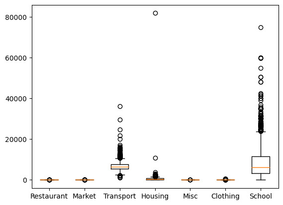

```python
plot = plt.boxplot([restaurant_costs_df['Average Cost'], market_costs_df['Average Cost'], transportation_costs_df['Average Cost'], housing_costs_df['Average Cost'], misc_costs_df['Average Cost'], clothing_costs_df['Average Cost'], school_costs_df['Average Cost']])

x_labels = ['Restaurant', 'Market','Transport', 'Housing', 'Misc', 'Clothing', 'School']
labels = plt.xticks([1, 2, 3, 4, 5, 6, 7], x_labels)
```

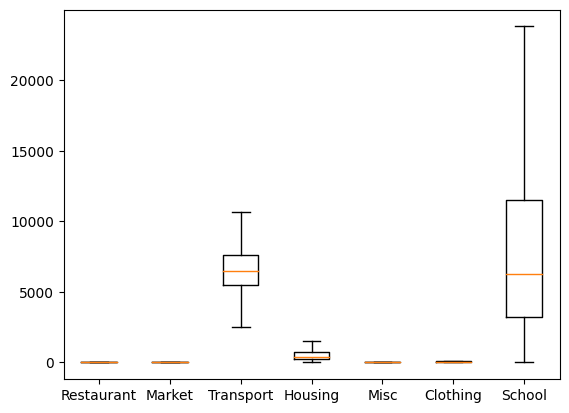

```python
without_outliers = plt.boxplot([restaurant_costs_df['Average Cost'], market_costs_df['Average Cost'], transportation_costs_df['Average Cost'], housing_costs_df['Average Cost'], misc_costs_df['Average Cost'], clothing_costs_df['Average Cost'], school_costs_df['Average Cost']], showfliers = False)

x_labels = ['Restaurant', 'Market','Transport', 'Housing', 'Misc', 'Clothing', 'School']
labels = plt.xticks([1, 2, 3, 4, 5, 6, 7], x_labels)
```

> When we look at this plot, we can see the correlation between the distributions of restaurant, market, clothing and miscellaneous cost distributions which look much more similar in comparison to the three other distributions when considering its spread/variance/standard deviation. When looking at this result, we can make sense of the data since food, clothing and other miscelaneous costs often have less varience when it comes to the price range in compariason to how schooling, transportation, and housing can be. This gives us some insight about certain factors and outliers when analyzing and comparing certain categories.

**Data Exploration Conclusions**

> Through our statistical methods, we were able to reason several strong correlations between the differing categories of living expenses with locations and average salaries. We deduced that there was a strong relationship between average salaries and cost of living within city centres, albeit with some outliers in the form of large cities with abnormally large living costs. We also found the significant different groups within the dataset via ANOVA test and Post-Hoc evaluation, leading us to believe that generally restaurant, market, clothing and miscellaneous costs were connected w/ no significant difference between them, while the other groups like housing, transportation and education had significant differences. In general, there were several outliers and variance because of how drastic living conditions can be in areas with a lower cost of living compared to higher population cities. Because of this we will use implications such as mode or median to ensure that the outliers do not have a substantial effect on our dataset. Finally, due to the size of our dataset it has become apparent that there may have been many other correlations between different columns that we haven't originally considered. Moving forward we will also split the datasets into smaller subsets to more effectively find more focused and detailed analysis.

**4. Primary Analysis**

In the previous section, we had found the cities that we would consider outliers as their total cost of living was much higher. For this section, we decided to do analysis for major cities, and separately for the others. According to our collected data for Low Living Cost Cities, there are no outliers on the lower side of our dataset, thus we will proceed by separating our data with only High Living cost and Average Living Cost cities.

```python
print("Outlier (High Living Cost) Cities: ")
high_lc = outliers_df[(outliers_df['z-score'] > 2)]['City']
print(high_lc)
print("Outlier (Low Living Cost) Cities: ")
low_lc = outliers_df[(outliers_df['z-score'] < (-2))]['City']
print(low_lc)
print("Non-Outlier (Average Living Cost) Cities: ")
print(non_outliers_cities)
```

```
Outlier (High Living Cost) Cities:
20           New York
24             Tehran
64          Hong Kong
103         Singapore
115            Boston
215            Havana
241           Esfahan
296            Tabriz
429            Niamey
507              Bern
529          Hamilton
578        Kermanshah
653            Tyumen
833            Ryazan
```

[output cut: 31 more lines]

Here we define lin_model a function that creates a linear regression model and fits our two datasets, outlier and non-outlier cities accordingly. It splits the data into training and testing data for the model to learn on. Then it uses matplotlib, a helpful library for creating visualizations, to plot both graphs side by side. We also calculate the Mean Squared Error (MSE) and the R^2 value to approximate how well our model fits our data. We will want to minimize our MSE and maximize our R^2 value as the closer to 0 our MSE value, and the closer our R^2 value to 1 the better. We will use this model to compare various categories of cost for our dataset.

```python
def lin_model(X1, y1, X2, y2, x_title):
  X1_train, X1_test, y1_train, y1_test = train_test_split(X1, y1, test_size = 0.2)
  X2_train, X2_test, y2_train, y2_test = train_test_split(X2, y2, test_size = 0.2)

  lm = LinearRegression().fit(X1_train, y1_train)
  predicted = lm.predict(X1_test)

  fig, axs = plt.subplots(1, 2, figsize=(18, 6))

  axs[0].scatter(X1_train, y1_train, color = 'red', label = 'Training Data')
  axs[0].scatter(X1_test, y1_test, color = 'blue', label = 'Testing Data')
  axs[0].plot(X1_test, predicted, color = 'orange', label = 'Linear Regression')
  axs[0].set_xlabel('Average Cost of a ' + x_title + ' in High Cost Living Cities')
  axs[0].set_ylabel('Average Monthly Net Salary (After Tax)')
  axs[0].set_title('Cost of ' + x_title + ' vs Net Salary For High Living Cost Cities')
  axs[0].legend()

  mse = mean_squared_error (y1_test, predicted)
  r2 = r2_score(y1_test, predicted)
  print("Higher Cost Cities:")
  print("MSE: ", mse, "R^2: ", r2)

  lm = LinearRegression().fit(X2_train, y2_train)
  predicted = lm.predict(X2_test)

  axs[1].scatter(X2_train, y2_train, color = 'red', label = 'Training Data')
  axs[1].scatter(X2_test, y2_test, color = 'blue', label = 'Testing Data')
  axs[1].plot(X2_test, predicted, color = 'orange', label = 'Linear Regression')
  axs[1].set_xlabel('Average Cost of a ' + x_title + ' in High Cost Living Cities')
  axs[1].set_ylabel('Average Monthly Net Salary (After Tax)')
  axs[1].set_title('Cost of ' + x_title + ' vs Net Salary for Average Living Cost Cities')
  axs[1].legend()

  mse = mean_squared_error (y2_test, predicted)
  r2 = r2_score(y2_test, predicted)
  print("Average Living Cost Cities:")
  print("MSE: ", mse, "R^2: ", r2)
```

In our section of exploratory data analysis we found that there were various categories in our datasets that may be from the same distribution. Due to this, we wanted to see if these categories had a similar correlation to average net salary when compared to each other.

As a referesher, we found that food, clothing and other miscelaneous costs were similar and schooling, transportation, and housing were grouped We wanted our main focus of analysis to be on necessities so we picked various features accordingly.

> For the upcoming analysis of our datasets, we split our dataset into two categories of cities, high and average living costs, according to the cities that were previously calculated as outliers vs non-outliers.Note that since our outlier dataset is smaller, the regression line is often inaccurate. Ideally we wish there was more data on high cost living cities, however we are unable to obtain more data.

**Food and Clothing**

```python
# Splitting into High Living Cost Cities and Average Living Cost Cities
outlier_restaurant_df = restaurant_costs_df[restaurant_costs_df['City'].isin(outlier_cities)]
regular_restaurant_df = restaurant_costs_df[restaurant_costs_df['City'].isin(non_outliers_cities)]
```

```
Higher Cost Cities:
MSE:  1373800.0634554245 R^2:  0.5969180816334662
Average Living Cost Cities:
MSE:  728149.247944001 R^2:  0.5898984318643792
```

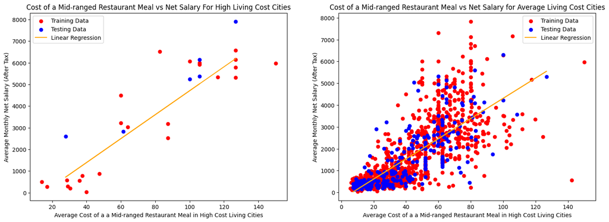

```python
mid_cost_restaurant = lin_model(outlier_restaurant_df['Mid-range Restaurant Meal'].values.reshape(-1, 1), outlier_restaurant_df['Average Monthly Net Salary (After Tax)'].values.reshape(-1, 1), regular_restaurant_df['Mid-range Restaurant Meal'].values.reshape(-1, 1), regular_restaurant_df['Average Monthly Net Salary (After Tax)'].values.reshape(-1, 1), "a Mid-ranged Restaurant Meal")
```

```
Higher Cost Cities:
MSE:  2899691.7176209297 R^2:  -1.1002116259328907
Average Living Cost Cities:
MSE:  730427.379406711 R^2:  0.550879854823588
```

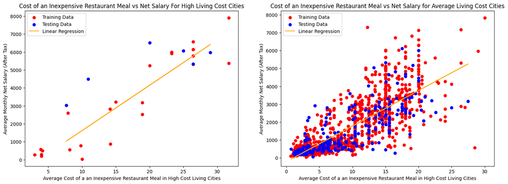

```python
inexpensive_cost_restaurant = lin_model(outlier_restaurant_df['Inexpensive Restaurant Meal'].values.reshape(-1, 1), outlier_restaurant_df['Average Monthly Net Salary (After Tax)'].values.reshape(-1, 1), regular_restaurant_df['Inexpensive Restaurant Meal'].values.reshape(-1, 1), regular_restaurant_df['Average Monthly Net Salary (After Tax)'].values.reshape(-1, 1), "an Inexpensive Restaurant Meal")
```

```
Higher Cost Cities:
MSE:  1006536.8321544393 R^2:  0.7593507971694471
Average Living Cost Cities:
MSE:  1042758.8714123904 R^2:  0.5577263352770196
```

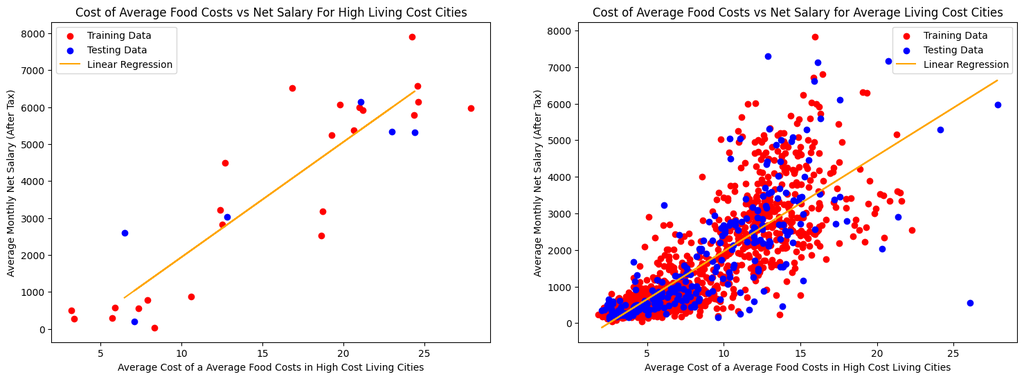

```python
average_food_costs = lin_model(outlier_restaurant_df['Average Cost'].values.reshape(-1, 1), outlier_restaurant_df['Average Monthly Net Salary (After Tax)'].values.reshape(-1, 1), regular_restaurant_df['Average Cost'].values.reshape(-1, 1), regular_restaurant_df['Average Monthly Net Salary (After Tax)'].values.reshape(-1, 1), "Average Food Costs")
```

Much like the previous observation, the linear regression models above indicate a strong correlation between average food costs and net salaries in average-high living cost cities. This tracks, due to food prices increasing according to the net salary of both high and average living cost cities to ensure most customers are satisfied with the pricings.

```
Higher Cost Cities:
MSE:  6280826.390663733 R^2:  -0.053990586014774467
Average Living Cost Cities:
MSE:  1713177.2349591479 R^2:  0.22447846103457858
```

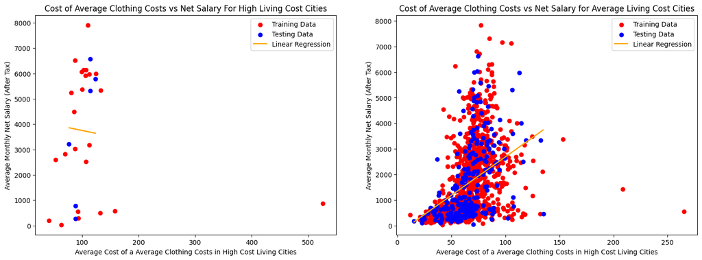

```python
outlier_clothing_df = clothing_costs_df[clothing_costs_df['City'].isin(outlier_cities)]
regular_clothing_df = clothing_costs_df[clothing_costs_df['City'].isin(non_outliers_cities)]
average_clothing_costs = lin_model(outlier_clothing_df['Average Cost'].values.reshape(-1, 1), outlier_clothing_df['Average Monthly Net Salary (After Tax)'].values.reshape(-1, 1), regular_clothing_df['Average Cost'].values.reshape(-1, 1), regular_clothing_df['Average Monthly Net Salary (After Tax)'].values.reshape(-1, 1), "Average Clothing Costs")
```

For the relations above, Linear Regression was utilized in order to accurately model the relationship between the average clothing costs and the net salary for average-high living cost cities. Interestingly, the high living cost cities model had a negative trend, perhaps due to the outlier, while the average living cost cities model had the expected positive trend. It should be noted that the R^2 scores for both models are low, perhaps due to the sparcity of the data.

**Housing and Transportation**

```
Higher Cost Cities:
MSE:  1900148.6414946395 R^2:  -3.2405266151344847
Average Living Cost Cities:
MSE:  56442.869337534525 R^2:  0.7775668290595095
```

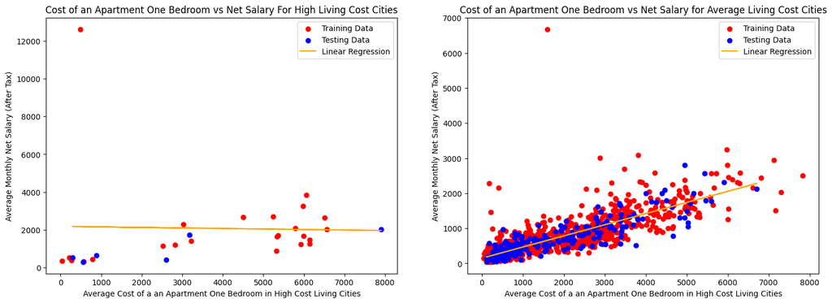

```python
outlier_housing_df = hypothesis_test_housing[hypothesis_test_housing['City'].isin(outlier_cities)]
regular_housing_df = hypothesis_test_housing[hypothesis_test_housing['City'].isin(non_outliers_cities)]
housing_regression = lin_model(outlier_housing_df['Average Monthly Net Salary (After Tax)'].values.reshape(-1, 1), outlier_housing_df['Apartment 1 bedroom in City Centre'].values.reshape(-1, 1), regular_housing_df['Average Monthly Net Salary (After Tax)'].values.reshape(-1, 1), regular_housing_df['Apartment 1 bedroom in City Centre'].values.reshape(-1, 1), "an Apartment One Bedroom")
```

Utilizing Linear Regression, the relationship between the average monthly net salary and cost for one apartment in a city becomes ever more apparent. Costs for one apartment in a city continue to surpass the average monthly net salary, with our machine learning algorithm predicting the average monthly salary to only be around \$2,000 per monthly net salary as opposed to the apartment cost of \$4,000 monthly. The gap between the average salary and costs drastically increases as the average salary rises, meaning that more people are left behind, unable to afford housing costs. As a result, the unemployment rates skyrocket from the influx of people who can no longer afford the living costs in areas with high average monthly salary, such as highly-populated cities. It should be noted that the lnear regression model for high living cost cities had a significantly lower R^2 value than the average living cost cities model.

```
Higher Cost Cities:
MSE:  5237833.917804349 R^2:  0.4510677081618867
Average Living Cost Cities:
MSE:  1858004.6765956418 R^2:  0.0972041991831274
```

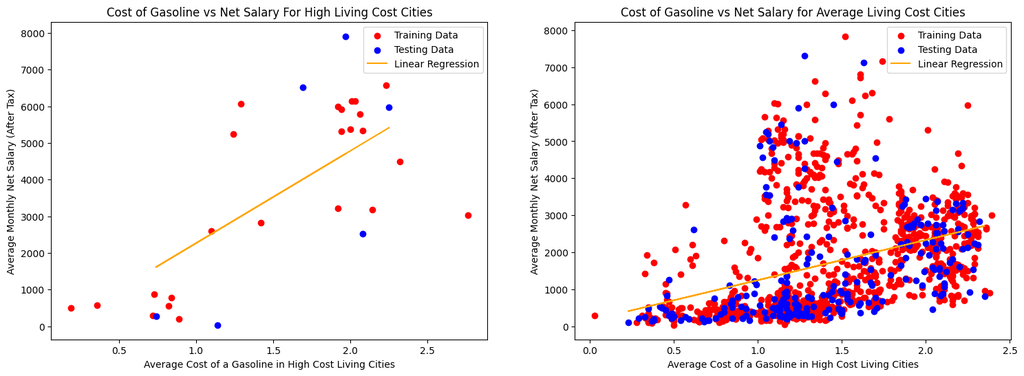

```python
outlier_transport_df = transportation_costs_df[transportation_costs_df['City'].isin(outlier_cities)]
regular_transport_df = transportation_costs_df[transportation_costs_df['City'].isin(non_outliers_cities)]
gassoline_regression = lin_model(outlier_transport_df['Gasoline'].values.reshape(-1, 1), outlier_transport_df['Average Monthly Net Salary (After Tax)'].values.reshape(-1, 1), regular_transport_df['Gasoline'].values.reshape(-1, 1), regular_transport_df['Average Monthly Net Salary (After Tax)'].values.reshape(-1, 1), "Gasoline")
```

In order to accurately model the relationship between average monthly salary and average cost of gasoline in both average-high cost living cities, Linear Regression models were once again implemented. As expected, both models had a postive trend indicating a correlation that as the average monthly salary rises in a city, the gas prices follow. While the high living cost cities model has fewer data points, it has a higher R^2 score than the average living cost cities model due to the latter having significantly more data points spread out.

```
Higher Cost Cities:
MSE:  9974555.80334691 R^2:  -0.861473292178959
Average Living Cost Cities:
MSE:  1825150.5277248432 R^2:  0.024221863066026472
```

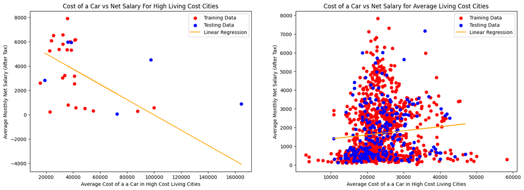

```python
car_regression = lin_model(outlier_transport_df['Toyota Corolla Sedan 1.6l 97kW Comfort'].values.reshape(-1, 1), outlier_transport_df['Average Monthly Net Salary (After Tax)'].values.reshape(-1, 1), regular_transport_df['Toyota Corolla Sedan 1.6l 97kW Comfort'].values.reshape(-1, 1), regular_transport_df['Average Monthly Net Salary (After Tax)'].values.reshape(-1, 1), "a Car")
```

For the relations above, Linear Regression was once again utilized in order to accurately model the relationship between the average monthly net salary and the average cost of a car in average-high living cost cities. Similarly to the clothing models, the high living cost cities model had an unexpected negative trend while the average living cost cities model had the expected positive trend. Due to the sparse nature of the training and testing data, both the models returned low R^2 scores.

```
Higher Cost Cities:
MSE:  1008224.0551614505 R^2:  0.4482473624854032
Average Living Cost Cities:
MSE:  1195906.985111927 R^2:  0.4071413104047168
```

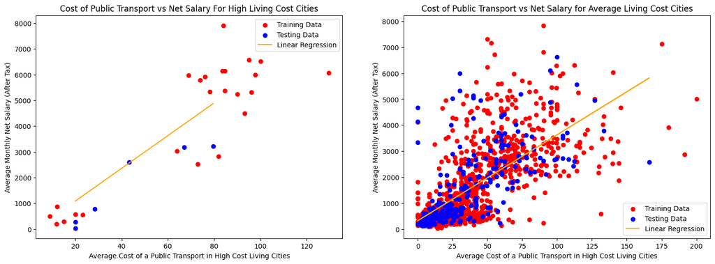

```python
public_transport_regression = lin_model(outlier_transport_df['Monthly Pass Tickets'].values.reshape(-1, 1), outlier_transport_df['Average Monthly Net Salary (After Tax)'].values.reshape(-1, 1), regular_transport_df['Monthly Pass Tickets'].values.reshape(-1, 1), regular_transport_df['Average Monthly Net Salary (After Tax)'].values.reshape(-1, 1), "Public Transport")
```

**Analyzing Inflation Rates**

Inflation is one of the contributing factors to the rising cost of living across the world. Especially when considering that wages do not fluctuate often, increasing inflation rates result in loss of purchasing power for the consumer. When considering the various necessities posed by this data set, we acknowledge that the rise of inflation rates definitely is a concern. Large proportions of salaries often are already allocated to important necessities such as housing, food and clothing. When considering the context of the rising rates, this only puts more of a strain on budgeting for people across the country and all around the world. The following section is an overview and prediction of how inflation has been changing over the years.

For the following section, we decided to incorporate another dataset, "inflation, interest, unemployment.csv". This dataset includes information about inflation, interest and unemployment rates of countries from 1970-2021. We also created the function Polynomial which creates a polynomial regression which can be applied to our dataset to see current trends and produce predictions.

```python
def Polynomial(X, y, country):

  poly = make_pipeline(PolynomialFeatures(degree =10), LinearRegression()).fit(X, y)
  predicted = poly.predict(X)

  fig, axs = plt.subplots(1, 2, figsize=(18, 6))

  axs[0].scatter(X, y)
  axs[0].set_title('Inflation Rate in the ' + country + ' over time')
  axs[0].set_ylabel('Inflation Rate')
  axs[0].set_xlabel('Year')

  axs[1].scatter(X, y, color = 'red', label = 'Data')
  axs[1].plot(X, predicted, color = 'orange', label = 'Polynomial Regression')
  axs[1].set_title('Inflation Rate in ' + country + ' over time')
  axs[1].set_ylabel('Inflation Rate')
  axs[1].set_xlabel('Year')
  axs[1].legend()

  mse = mean_squared_error (y, predicted)
  r2 = r2_score(y, predicted)
  print("MSE: ", mse, "R^2: ", r2)

  print("Inflation Prediction 2023: ", poly.predict(np.array(2023).reshape(-1,1)))
  print("Inflation Prediction 2025: ", poly.predict(np.array(2025).reshape(-1,1)))
```

Our second dataset was more difficult to parse, as seen below, rows were categorized by country and year with multiple entries for the same country. As a result, we used the function pivot_table to help create a data frame which would index by country and use years for the columns. The values of the table includes infromation about inflation rates over the years.

Inflation has a significant role on the purchasing power of money, and in turn the overall prices of goods and services over time. As inflation rates increase, so does the currency value in the market, its purchasing power. An increase of inflation results in rising prices for essential goods and services, drastically increasing the overall cost of living per person. In addition, if a person's wages don't account for an increase of inflation, their true income value decreases according to the currency value, further increasing the difficulty for people who already struggling to get by the higher cost of living.

```python
inflation_df = pd.read_csv('inflation interest unemployment.csv')
print(inflation_df)
```

```
           country  year  Inflation, consumer prices (annual %)  \
0      Afghanistan  1970                                    NaN
1      Afghanistan  1971                                    NaN
2      Afghanistan  1972                                    NaN
3      Afghanistan  1973                                    NaN
4      Afghanistan  1974                                    NaN
...            ...   ...                                    ...
13827     Zimbabwe  2017                                   0.89
13828     Zimbabwe  2018                                  10.62
13829     Zimbabwe  2019                                 255.30
13830     Zimbabwe  2020                                 557.20
13831     Zimbabwe  2021                                    NaN

       Inflation, GDP deflator (annual %)  Real interest rate (%)  \
0                                     NaN                     NaN
```

[output cut: 77 more lines]

```
MSE:  3.882922576281755 R^2:  0.5189081393272603
Inflation Prediction 2023:  [[4.1022717]]
Inflation Prediction 2025:  [[5.12173509]]
```

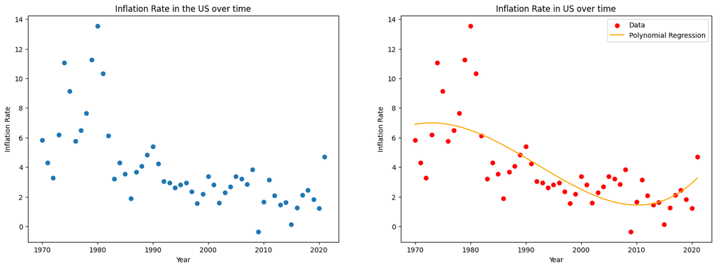

```python
inflation_df = inflation_df.pivot_table(index='country', columns='year', values='Inflation, consumer prices (annual %)')
US_inflation = inflation_df.loc['United States']

us = Polynomial(pd.array(US_inflation.index).reshape(-1, 1), pd.array(US_inflation.values).reshape(-1, 1), "US")
```

Accoring to the [Census Bureau](https://www.census.gov/foreign-trade/statistics/highlights/toppartners.html), the top countries we trade with is China, Canada and Japan. Since trade and inflation rates have such a strong impact on supply and demand and thus market costs, we wanted to compare the inflation rates of our major traders.

```
MSE:  23.600997125108563 R^2:  0.36876654998924674
Inflation Prediction 2023:  [[2.9989596]]
Inflation Prediction 2025:  [[3.39400037]]
```

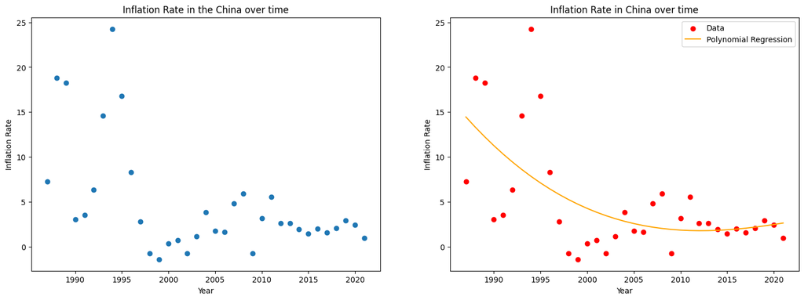

```python
CH_inflation = inflation_df.loc['China']
china = Polynomial(pd.array(CH_inflation.index[17:]).reshape(-1, 1), pd.array(CH_inflation.values[17:]).reshape(-1, 1), "China")
```

```
MSE:  3.7993560837955362 R^2:  0.6131838236408491
Inflation Prediction 2023:  [[4.85641604]]
Inflation Prediction 2025:  [[6.39296465]]
```

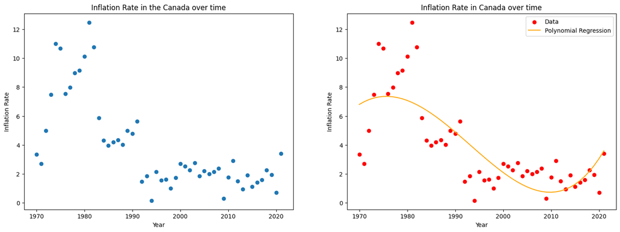

```python
CA_inflation = inflation_df.loc['Canada']

canada = Polynomial(pd.array(CA_inflation.index).reshape(-1, 1), pd.array(CA_inflation.values).reshape(-1, 1), "Canada")
```

For the inflation rate in Canada, we once again utilized Polynomial Regression to better account for the shape of our data. Through the model we were able to surmise that like the US, the inflation rates have been on a downward trend since 1970, but also had a significant rise of inflation rates since 2010.

```
MSE:  7.010399370650737 R^2:  0.6137630395829354
Inflation Prediction 2023:  [[1.11291591]]
Inflation Prediction 2025:  [[1.36652998]]
```

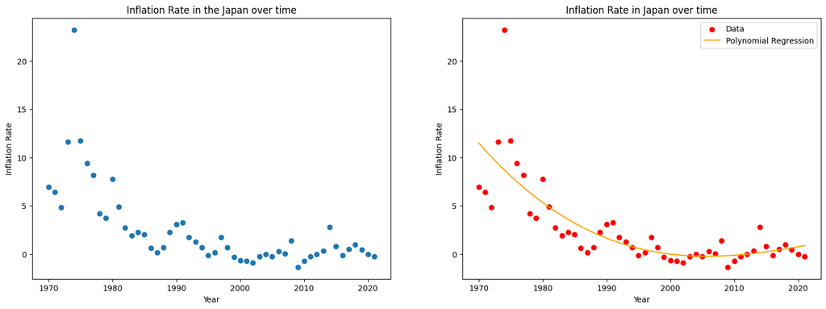

```python
JP_inflation = inflation_df.loc['Japan']

japan = Polynomial(pd.array(JP_inflation.index).reshape(-1, 1), pd.array(JP_inflation.values).reshape(-1, 1), "Japan")
```

Once again, we utilized Polynomial Regression to more accurately represent the change in Japan's inflation rate over time. Through the model we were able to surmise that while the inflation rates have been on a steady downward trend since 1970, the inflation rate has since maintained around an average of 0-0.8%.

Additionally, our second dataset included information about unemployment which is a major concern among our generation. As a result, we decided to create a similar dataset including information about unemployment from 1970-2021. To hone in on the effect of unemployment and cost of living in the context of our community, we decided to extract data about US' unemployment rates. To help us better understand how unemployment and overall income relates to inflation and cost of living we visualized the following compariasons. This will assist us in determining our overall insight and conclusions.

```python
country_outliers = outliers_df.groupby('Country', as_index=False)['Total Costs'].mean()
inflation_df = pd.read_csv('inflation interest unemployment.csv')
inflation_df = inflation_df.pivot_table(index='country', columns='year', values='Unemployment, total (% of total labor force) (national estimate)')
unemployment_df = inflation_df.join(country_outliers.set_index('Country'), on = 'country')
```

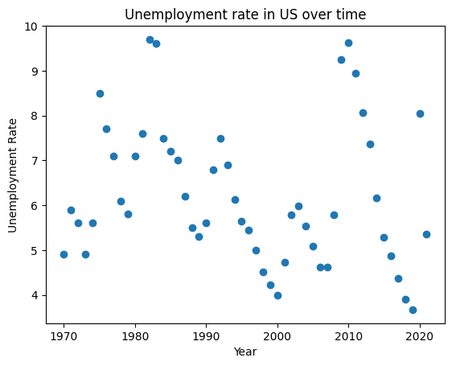

```python
US_unemployment = unemployment_df.loc['United States']
US_unemployment.index
plt.scatter(pd.array(US_unemployment.index[:52]).reshape(-1, 1), pd.array(US_unemployment.values[:52]).reshape(-1, 1))
plt.title('Unemployment rate in US over time')
plt.ylabel('Unemployment Rate')
plt.xlabel('Year')
plt.show()
```

When analyzing the graph, we see that unemployment is heavily variable. From 2010 unemployment seemed to be trending downwards, but due to covid we see that in 2020 unemployment rose again. For the rest of the graph, unemployment rates seemed to be steadily declining, but it seems impossible to predict the future rate due to outside factors that could affect the economy.

Finally, we create one last graph to help wrap up our analysis on our datasets. Using the "Inflation Interest Unemployment" dataset, we create a dataframe with columns focusing on the income level and overall costs of each countries. Especially pertaining to the questions posed in the introduction, we wanted to understand better if countries have overall Total Costs that are proportional to their income levels.

```python
income_df = pd.read_csv('inflation interest unemployment.csv')
income_df.drop_duplicates(subset=['country'], inplace = True, keep = 'last')
income_df = pd.concat((income_df['country'], income_df['incomeLevel']), axis = 1)
income_df.rename(columns = {'country':'Country', 'incomeLevel':'Income Level'}, inplace = True)

# Here we see that one of our categories is Not Classified, thus we fill NaN values with the Not classified value
print(income_df['Income Level'].unique())
income_df.fillna('Not classified', inplace=True)
income_df = income_df.join(country_outliers.set_index('Country'), on = 'Country')
income_df = income_df.dropna()
income_df
```

```
['Low income' 'Aggregates' 'Upper middle income' 'Lower middle income'
 'High income' nan 'Not classified']
```

|  | Country | Income Level | Total Costs |
| --- | --- | --- | --- |
| 207 | Albania | Upper middle income | 42,352.23 |
| 259 | Algeria | Lower middle income | 52,975.53 |
| 415 | Angola | Lower middle income | 68,885.74 |
| 571 | Argentina | Upper middle income | 61,810.45 |
| 623 | Armenia | Upper middle income | 69,026.24 |
| ... | ... | ... | ... |
| 13207 | United States | High income | 87,571.71 |
| 13311 | Uruguay | High income | 88,121.32 |
| 13363 | Uzbekistan | Lower middle income | 35,371.36 |
| 13519 | Vietnam | Lower middle income | 87,964.91 |
| 13831 | Zimbabwe | Lower middle income | 65,922.99 |

128 rows × 3 columns

Here, we use the function describe to find our lower, lower middle, upper middle and upper quartiles for categorization.

```python
print(income_df['Total Costs'].describe())
```

```
count       128.00
mean     68,819.91
std      39,282.48
min      23,352.42
25%      48,895.13
50%      61,989.92
75%      75,254.25
max     348,248.40
Name: Total Costs, dtype: float64
```

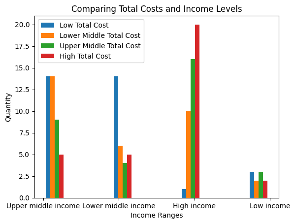

```python
lowest_quarter = income_df[income_df['Total Costs'] < 48895.13]['Income Level']
lower_middle = income_df[(income_df['Total Costs'] >= 48895.13) & (income_df['Total Costs'] < 61989.92)]['Income Level']
upper_middle = income_df[(income_df['Total Costs'] >= 61989.92) & (income_df['Total Costs'] < 75254.25)]['Income Level']
highest_quarter = income_df[income_df['Total Costs'] > 75254.25]['Income Level']
plt.hist([lowest_quarter, lower_middle, upper_middle, highest_quarter], label = ['Low Total Cost', 'Lower Middle Total Cost', 'Upper Middle Total Cost', 'High Total Cost'])
plt.legend()
plt.xlabel('Income Ranges')
plt.ylabel('Quantity')
plt.title('Comparing Total Costs and Income Levels')
plt.show()
```

```python
income_df[income_df['Country'] == 'United States']
```

|  | Country | Income Level | Total Costs |
| --- | --- | --- | --- |
| 13207 | United States | High income | 87,571.71 |

Through the categorization in our histogram, we can see that there is an overall positive correlation between total cost of living and income levels. However, when considering the broader perspective, it seems that creating these generalizations is quite dangerous. According to our dataset, the United States is considered one of the countries that have high costs of living and at the same time high average net salary. When considering the general population and the drastic disparities between economic classes, we note that there are definitely shortcomings when making decisions purely based on our data set. In reality, despite having a high income level, there is most definitely a wide range of economic classes across our country. Considering that our overall cost of living is high, a large portion of our population most definitely struggles to pay for necessities.

**5. Insights and Conclusions**

Based on our extensive data analysis and data modeling through linear and polynomial regression,the importance of inflation became ever more apparent. As further predicted by our polynomial regression models, inflation rates throughout several countries have been steadily decreasing since 1970 but show signs of either stabilizing or starting to climb in the past couple of years. Inflation has a significant impact on the cost of living, and as such our models predict that the cost of living may also rise in the next couple years to account for inflation, as the prices for everyday goods and services rise with inflation.

Another evaluation is that certain aspects of living costs have significantly less correlation with average net salary than initially predicted, especially when compared with other necessities. While housing and food costs would drastically increase to account for areas with higher average salaries, clothing costs tended to remain the same cost regardless. This is perhaps due to the fact that clothing costs tend to follow industry pricing and have a stable consumer base willing to meet the costs, while housing and food costs tend to need to change pricings accordingly to maximize sales in different environments.

Most importantly, our models would often generalize the behaviors of an entire country utilizing the averages found in our dataset. While our models provide a good picture of the general behaviors and trends each country may have, it is important to remember that for each average we use, there is an economic disparity that is not properly represented. Our models may effectively find trends to further focus on, but in order to enact real change for the people, it is important to engage in further research on the people whose livelihoods are being directly affected. Each data point has a story behind them, and it is important to acknowledge this in order to better understand and aid the community.